# One–Way Analysis of Variance Using R (Using RStudio)

One–Way Analysis of Variance Using R (Using RStudio)

## When to use a One-Way ANOVA

A **one-way analysis of variance (ANOVA)** is a statistical test that can be used to assess whether the mean value of some outcome variable is different between three or more groups.

The observations/measurements on the outcome variable must be Scale data, such as weight, where you might want to compare the mean weight of the population of several different countries. The groups must be independent of each other, for example each person’s weight measurement is included in only one country.

If your measurements are Ordinal, then consider a Kruskal Wallis test instead.

If you wish to compare just two groups, then you can use ANOVA, but a better simpler alternative is to use an independent samples t-test.

For more help on “What test do I need” go to the **sigma** website [statistical worksheets resources](https://libguides.coventry.ac.uk/c.php?g=712076&p=5146769) page.

## Example

A paper bag manufacturer investigated the impact of varying hardwood fibre concentrations (5%, 10%, 15%, and 20%) on the tensile strength of their products, measured in pounds per square Inch (psi). Six test specimens were produced at each concentration level, resulting in 24 bags being tested. The data shown below can be downloaded in a CSV file called hardwood.csv:

[figure not shown]

The research question aimed to determine if there existed a significant difference in mean tensile strengths among the four hardwood concentration levels.

**To address this, a one-way ANOVA was conducted, testing the following hypotheses:**

H0: There **is no difference** in mean tensile strength between the four hardwood concentrations.

H1: There **is a difference** in mean tensile strength between at least two of the hardwood concentrations.

The data has two columns. The first column, Conc, represents the independent or grouping variable, where 1 means 5% hardwood concentration, 2 means 10% hardwood concentration, and so on. The second column, Strength, contains all the tensile strength measurements.

## Importing the data into R

To get started with the analysis, first, bring the dataset into RStudio. To do this you can either run a read.csv() function if you know how to do this or alternatively you can follow the following steps using the menus:

From the **File** menu select **Import Dataset** then **From Text(base)**:

[figure not shown]

From the pop-up window navigate to the folder **where you have saved the dataset**, then once the file was selected click “Open”:

[figure not shown]

At the next dialogue box (see below), in the upper left corner in the **“Name”** field, amend the name of your dataset if you wish, in this example we named it as **“hardwood”**.

We should also make sure the **Heading** option below is set to **Yes** (otherwise the data will all be read in as text):

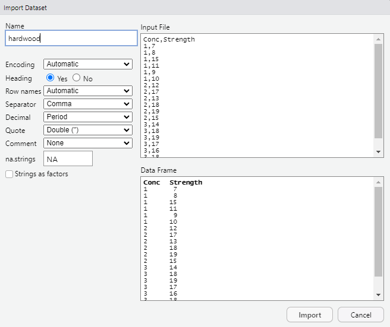

Finally, click on **“Import”** to complete the process. This imports the data set and is listed in the **“Environment”** in the top right of your RStudio screen as follows:

[figure not shown]

## Using R

Begin by obtaining descriptive statistics of strengths for each concentration level.

```r
tapply(hardwood$Strength, hardwood$Conc, summary)
```

Next, we will create a descriptive plot showing mean strengths over concentration. To do this, we first calculate and store the means, and then plot these on a line plot.

```r
mean_strengths <- tapply(hardwood$Strength, hardwood$Conc, mean)
plot(mean_strengths, type="l", xlab="Conc", ylab="Strength")
```

Finally, we will carry out **One-Way ANOVA** using the function **aov()**. First, we need to convert **Conc** to a factor. To obtain the results we want, we will need a **summary** of the results.

```r
hardwood$Conc <- as.factor(hardwood$Conc)
anova <- aov(hardwood$Strength ~ hardwood$Conc, type=III)
summary(anova)
```

## Examining the Output

The descriptive statistics and plot can be seen below:

```
## $`1`
##    Min. 1st Qu.  Median    Mean 3rd Qu.    Max.
##    7.00    8.25    9.50   10.00   10.75   15.00
##
## $`2`
##    Min. 1st Qu.  Median    Mean 3rd Qu.    Max.
##   12.00   13.50   16.00   15.67   17.75   19.00
##
## $`3`
##    Min. 1st Qu.  Median    Mean 3rd Qu.    Max.
##   14.00   16.25   17.50   17.00   18.00   19.00
##
## $`4`
##    Min. 1st Qu.  Median    Mean 3rd Qu.    Max.
##   18.00   19.25   21.00   21.17   22.75   25.00
```

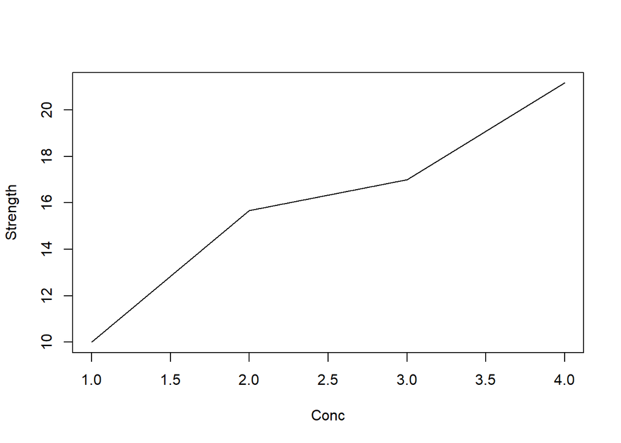

Note: To generate plots in R, we need to indicate the data or variables we want to plot. We can do that by indicating which columns in our dataset contain that data, for the case of Rstudio, we can type the name of our dataset followed by a dollar sign **“$”** and the name of our column that contains the data as in the snippet of code above. Additionally, to add labels, we can add them by using the xlab and ylab options inside the function as seen in the code provided.

The descriptives statistics provide statistics for tensile strength for the different wood concentrations. The dscriptives plot show that in our samples, the higher the concentration, the higher the mean tensile strength, ranging from 10.00 psi at 5% to 21.17 psi at 20%. although we note there appears to be less difference in strength between the 10% concentration (15.67 psi) and the 15% concentration (17.00 psi).

```
##               Df Sum Sq Mean Sq F value   Pr(>F)
## hardwood$Conc  3  382.8  127.60   19.61 3.59e-06 ***
## Residuals     20  130.2    6.51
## ---
## Signif. codes:  0 '***' 0.001 '**' 0.01 '*' 0.05 '.' 0.1 ' ' 1
```

However, the ANOVA test only tells us that there is a difference somewhere, not where specifically, which is why we need to undergo post hoc tests to identify where the differences lie.

## Post-hoc tests

The nature of these differences can be explored further by performing **post hoc** tests to drill down into the results, but only if the ANOVA test has been found to be statistically significant, as in our case. Post-hoc tests identify any significant differences in mean scores between all possible pairs of the factor levels, in our case pairs of concentration levels. In effect they are variations on t-tests comparing each pair of means.

To obtain the post hoc tests, we apply the function **TukeyHSD()** to the anova model previously fit:

```r
TukeyHSD(anova)
```

```
##   Tukey multiple comparisons of means
##     95% family-wise confidence level
##
## Fit: aov(formula = hardwood$Strength ~ hardwood$Conc, type = III)
##
## $`hardwood$Conc`
##          diff         lwr       upr     p adj
## 2-1  5.666667  1.54410408  9.789229 0.0051108
## 3-1  7.000000  2.87743741 11.122563 0.0006501
## 4-1 11.166667  7.04410408 15.289229 0.0000015
## 3-2  1.333333 -2.78922925  5.455896 0.8022275
## 4-2  5.500000  1.37743741  9.622563 0.0065966
## 4-3  4.166667  0.04410408  8.289229 0.0470251
```

Because our factor has 4 levels, there are a total of 6 possible pairings.

Careful examination of the R output indicates a statistically significant difference in mean strength between: 5% and 10%, 5% and 15%, 5% and 20% (p=0.005, p<0.001 and p<0.001, respectively), 10% and 20% (p=0.007), and 15% and 20% (p=0.047). However, there was no statistically significant difference between 10% and 15% (p=0.802).

## Further Work

To further enhance our results, we need to compute eta-squared for practical significance and assess normality plus homogeneity of variances. This will ensure that our one-way ANOVA results are robust enough.

### Normality

For the test to be valid it should be reasonable to assume that the measurements in each group are approximately normally distributed. If we have 30 or more measurements in each group, then we can safely make that assumption and need not check this any further.

Since we only had 6 measurements in each group, we need to do some further assessments. However, when we only have very small samples, it can sometimes be quite a challenge to determine whether the data in each group come from a normal distribution or not.

Hence, the best way to assess normality for one-way ANOVA is to repeat the main analysis but save what are called the residuals. The residuals are the differences between each observed value and the mean value for that group. We then need to check if this single column of residuals can be assumed to be normally distributed.

We can obtain the residuals using the function **residuals()** applied to our anova model. These can then be plotted in a **histogram**:

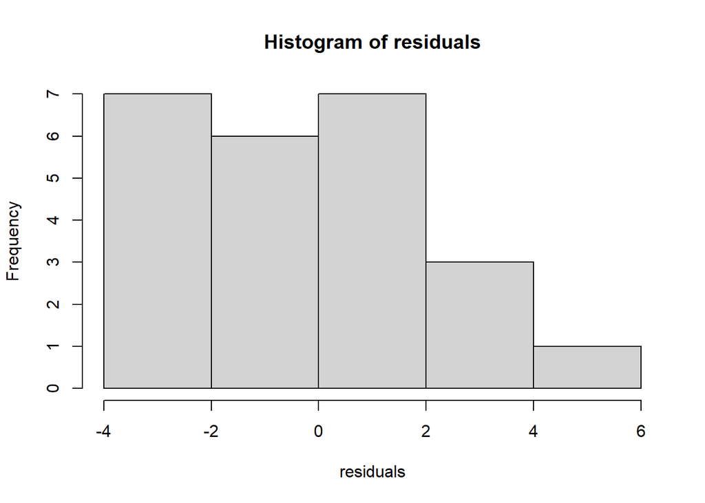

```r
residuals <- residuals(anova)
hist(residuals)
```

Normality could be judged by examining the shape of the histogram to see if it makes a roughly symmetric bell-shaped curve. However, small sample sizes tend to make the histogram look ‘jagged’, making it harder to discern normality by eye. It is probably better to assess normality using the Shapiro-Wilk test:

```r
shapiro.test(residuals)
```

```
##
##  Shapiro-Wilk normality test
##
## data:  residuals
## W = 0.96624, p-value = 0.5757
```

### Equal variances

The ANOVA test we undertook also assumes homogeneity (equality) of variance. This essentially means, can we assume the amount by which the tensile strength varies amongst bags with 10% concentration hardwood, is the same amount the strength of bags with 15% varies and so on?

Levene’s test is used in R to evaluate the homogeneity of variance assumption.

First, install the package **car**. Then, apply the **library()** function to this. This will give us access to the function **LeveneTest()** which we will use next.

```r
install.packages("car", repos="https://cloud.r-project.org")
library(car)
```

Note: to add additional functions to Rstudio we can install external packages. These can add more capabilities not present in the default Rstudio or when there is no other way to carry on an analysis. After installing the package we need to call it by using **library()**. This will indicate Rstudio to use the functions inside this package to run calculations or procedures requested by the user.

```r
hardwood$Conc <- as.factor(hardwood$Conc)
leveneTest(Strength ~ Conc, data = hardwood)
```

|  | Df | F value | Pr(>F) |
| --- | --- | --- | --- |
| group | 3 | 0.5988456 | 0.6231941 |
|  | 20 | NA | NA |

```r
oneway.test(Strength ~ Conc, data = hardwood, var.equal = FALSE)
```

We would then report the p value for the overall ANOVA from the output shown below, rather than from the main ANOVA table we saw earlier:

```
##
##  One-way analysis of means (not assuming equal variances)
##
## data:  Strength and Conc
## F = 15.253, num df = 3.000, denom df = 10.873, p-value = 0.0003262
```

For more resources, see sigma.coventry.ac.uk Adapted from material developed by Coventry University